# Live Session Unit 4 Assignment

Alec Neff

6/9/2018

## 1. FiveThirtyEight Data

1. Install the fivethirtyeight package.

```r
install.packages("fivethirtyeight",repos = "https://cran.rstudio.com/")
```

2. In the listing of Data sets in package ‘fivethirtyeight’, assign the eighteenth data set to an object ‘df’.

```r
data(package="fivethirtyeight")
data("college_recent_grads",package = "fivethirtyeight")
df<-college_recent_grads
```

3. Use a more detailed list of the data sets to write out the URL in a comment to the related news story.

The data can be found at: https://github.com/rudeboybert/fivethirtyeight/blob/master/data/college_recent_grads.rda

4. Using R command(s), give the dimensions and column names of this data frame.

```r
str(df)
```

```
## Classes 'tbl_df', 'tbl' and 'data.frame':    173 obs. of  21 variables:
##  $ rank                       : int  1 2 3 4 5 6 7 8 9 10 ...
##  $ major_code                 : int  2419 2416 2415 2417 2405 2418 6202 5001 2414 2408 ...
##  $ major                      : chr  "Petroleum Engineering" "Mining And Mineral Engineering" "Metallurgical Engineering" "Naval Architecture And Marine Engineering" ...
##  $ major_category             : chr  "Engineering" "Engineering" "Engineering" "Engineering" ...
##  $ total                      : int  2339 756 856 1258 32260 2573 3777 1792 91227 81527 ...
##  $ sample_size                : int  36 7 3 16 289 17 51 10 1029 631 ...
##  $ men                        : int  2057 679 725 1123 21239 2200 2110 832 80320 65511 ...
##  $ women                      : int  282 77 131 135 11021 373 1667 960 10907 16016 ...
##  $ sharewomen                 : num  0.121 0.102 0.153 0.107 0.342 ...
##  $ employed                   : int  1976 640 648 758 25694 1857 2912 1526 76442 61928 ...
##  $ employed_fulltime          : int  1849 556 558 1069 23170 2038 2924 1085 71298 55450 ...
##  $ employed_parttime          : int  270 170 133 150 5180 264 296 553 13101 12695 ...
##  $ employed_fulltime_yearround: int  1207 388 340 692 16697 1449 2482 827 54639 41413 ...
##  $ unemployed                 : int  37 85 16 40 1672 400 308 33 4650 3895 ...
##  $ unemployment_rate          : num  0.0184 0.1172 0.0241 0.0501 0.0611 ...
##  $ p25th                      : num  95000 55000 50000 43000 50000 50000 53000 31500 48000 45000 ...
##  $ median                     : num  110000 75000 73000 70000 65000 65000 62000 62000 60000 60000 ...
##  $ p75th                      : num  125000 90000 105000 80000 75000 102000 72000 109000 70000 72000 ...
##  $ college_jobs               : int  1534 350 456 529 18314 1142 1768 972 52844 45829 ...
##  $ non_college_jobs           : int  364 257 176 102 4440 657 314 500 16384 10874 ...
##  $ low_wage_jobs              : int  193 50 0 0 972 244 259 220 3253 3170 ...
```

## 2. Data Summary

1. Write an R command that gives you the column names of the data frame. Right after that, write one that counts the number of columns but not rows. Hint: the number should match one of your numbers in Question 1d for dimensions.

```r
colnames(df)
```

```
##  [1] "rank"                        "major_code"
##  [3] "major"                       "major_category"
##  [5] "total"                       "sample_size"
##  [7] "men"                         "women"
##  [9] "sharewomen"                  "employed"
## [11] "employed_fulltime"           "employed_parttime"
## [13] "employed_fulltime_yearround" "unemployed"
## [15] "unemployment_rate"           "p25th"
## [17] "median"                      "p75th"
## [19] "college_jobs"                "non_college_jobs"
## [21] "low_wage_jobs"
```

```r
ncol(df)
```

```
## [1] 21
```

2. Generate a count of each unique major_category in the data frame. I recommend using libraries to help. I have demonstrated one briefly in live-session. To be clear, this should look like a matrix or data frame containing the major_category and the frequency it occurs in the dataset. Assign it to major_count.

```r
major_count<-table(df$major_category)
major_count
```

```
##
##     Agriculture & Natural Resources                                Arts
##                                  10                                   8
##              Biology & Life Science                            Business
##                                  14                                  13
##         Communications & Journalism             Computers & Mathematics
##                                   4                                  11
##                           Education                         Engineering
##                                  16                                  29
##                              Health           Humanities & Liberal Arts
##                                  12                                  15
## Industrial Arts & Consumer Services                   Interdisciplinary
##                                   7                                   1
##                 Law & Public Policy                   Physical Sciences
##                                   5                                  10
##            Psychology & Social Work                      Social Science
##                                   9                                   9
```

or

```r
as.matrix(major_count)
```

```
##                                     [,1]
## Agriculture & Natural Resources       10
## Arts                                   8
## Biology & Life Science                14
## Business                              13
## Communications & Journalism            4
## Computers & Mathematics               11
## Education                             16
## Engineering                           29
## Health                                12
## Humanities & Liberal Arts             15
## Industrial Arts & Consumer Services    7
## Interdisciplinary                      1
## Law & Public Policy                    5
## Physical Sciences                     10
## Psychology & Social Work               9
## Social Science                         9
```

3. To make things easier to read, enter par(las=2) before your plot to make the text perpendicular to the axis. Make a barplot of major_count. Make sure to label the title with something informative (check the vignette if you need), label the x and y axes, and make it any color other than grey. Assign the major_category labels to their respective bars. Flip the barplot horizontally so that bars extend to the right, not upward. All of these options can be done in a single pass of barplot(). Note: it’s okay if it’s wider than the preview pane. *I think labelling the y axis here is problematic to appearances and is superfluous as the bar names serve are self-explanatory considering Major Category is included in the title.

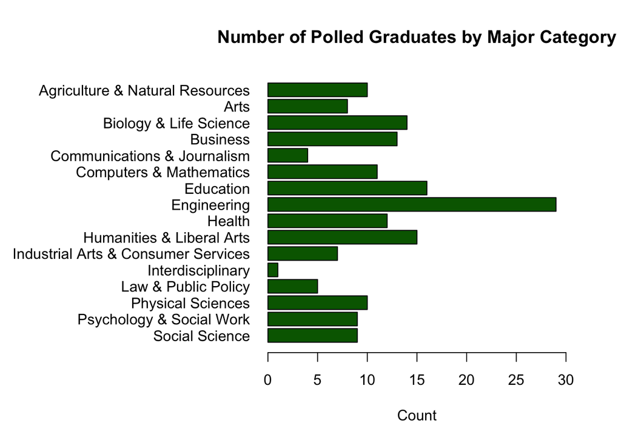

```r
par(las=1,mar=c(5.1,15.1,4.1,3.1))
barplot(as.matrix(major_count)[16:1],main = "Number of Polled Graduates by Major Category",xlab = "Count",horiz = TRUE,col = "darkgreen",names.arg = row.names(major_count)[16:1],xlim = c(0,30))
```

4. Write the fivethirtyeight data to a csv file. Make sure that it does not have row labels.

```r
write.csv(df,file = "/Users/acneff/Documents/Data_Science/School/DDS/HW4/fte_college_recent_grads.csv",row.names = FALSE)
```

## 3. Codebook

a-c: see link in d

4. In your RMarkdown script, please provide the link to this GitHub so the grader can see it.

https://github.com/acneff/smu_msds_hw

## Thanks for joining me. Come back when you can stay longer!